# Linear Model Analysis Project Report

Group 4

Authors

Duc Kien Doan

Nabat Isgandarova

Santiago Parra

Published

December 22, 2025

# 1 Introduction

This project examines the condition of various bridges in the US. The dataset has information about the bridge condition and some covariates that can help in explaining that condition. This report summarizes the process of exploratory data analysis (EDA), proposing a linear regression model with its interpretation and diagnostics, and finally make some prediction for new data. The variables in the dataset are as follows:

- `Urban`: Whether the bridge is in an urban or rural area
- `Year`: The year the bridge was built
- `Lanes_on`: Number of traffic lanes on the bridge
- `AverageDaily`: The average daily traffic (number of vehicles)
- `Historic`: Whether the bridge is historic
- `Material`: The dominant material the bridge is made from
- `Spans`: Number of spans of the bridge
- `Length`: The length of the bridge (m)
- `Width`: The width of the bridge (m)
- `Trucks_percent`: The percentage of traffic made up of trucks

# 2 Data Preparation

We now load the data, assuming that the two `.csv` files are in `data` folder. Based on the dataset description, we know that `Urban`, `Historic`, and `Material` are categorical covariates, which corresponds to `factor` in R.

```r
data <- read_csv("data/group_04.csv", col_types = cols(
  Urban = col_factor(),
  Historic = col_factor(),
  Material = col_factor(),
))
```

We now take a quick look at summary of the data. As we can see, there are 10 covariates, 3 of which are categorical. The minimum and maximum values of all variables but `Spans` are reasonable. Since bridges with 0 spans do not exist, we decide to remove these cases in the data. In addition, the striking low number of bridges built with `Masonry` compared to other materials could lead to low precision (high standard error) when estimating model coefficients. With that low number, we also cannot make any conclusion about bridges built with masonry. Therefore, we decide to join `Masonry` and `Other` into one level.

```r
summary(data)
```

```
 Structure_id         Urban            Year         Lanes_on
 Length:30186       Rural:16343   Min.   :1900   Min.   : 1.00
 Class :character   Urban:13843   1st Qu.:1964   1st Qu.: 2.00
 Mode  :character                 Median :1985   Median : 2.00
                                  Mean   :1982   Mean   : 2.39
                                  3rd Qu.:2002   3rd Qu.: 2.00
                                  Max.   :2019   Max.   :15.00
  AverageDaily            Historic         Material         Spans
 Min.   :     0   Not historic:17549   Concrete:23888   Min.   :  0.000
 1st Qu.:   330   Possible    :12215   Timber  :  415   1st Qu.:  1.000
 Median :  3280   Register    :  373   Steel   : 5831   Median :  3.000
 Mean   : 11594   Unknown     :   49   Other   :   41   Mean   :  3.752
 3rd Qu.: 11850                        Masonry :   11   3rd Qu.:  4.000
 Max.   :543000                                         Max.   :194.000
     Length            Width        Trucks_percent     Condition
 Min.   :   6.10   Min.   :  2.50   Min.   : 0.000   Min.   : 0.0
 1st Qu.:  24.40   1st Qu.:  7.30   1st Qu.: 0.000   1st Qu.:19.0
 Median :  47.20   Median : 10.90   Median : 5.000   Median :21.0
 Mean   :  91.92   Mean   : 11.79   Mean   : 8.586   Mean   :20.3
 3rd Qu.:  87.80   3rd Qu.: 13.40   3rd Qu.:13.000   3rd Qu.:22.0
 Max.   :6270.30   Max.   :196.60   Max.   :99.000   Max.   :27.0
```

```r
data <- data |> filter(Spans > 0)
data$Material <- forcats::fct_collapse(data$Material, Other = c("Masonry", "Other"))
```

# 3 Exploratory Data Analysis

## 3.1 Numerical covariates

We first take a look at the numeric covariates and their distribution. To achieve this, we plot their histograms, shown in Figure 1.

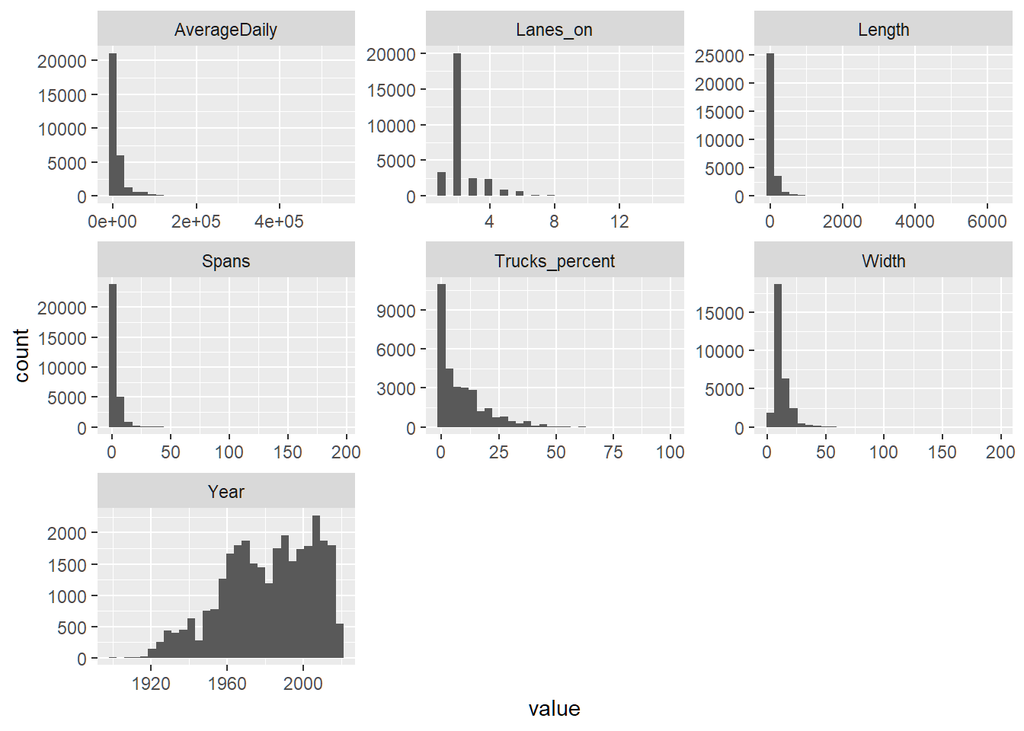

Figure 1: Histogram of all numeric covariates.

```r
data |>
  select(where(is.numeric), -c(Condition)) |>
  pivot_longer(everything(), names_to = "covariate") |>
  ggplot() +
  geom_histogram(aes(x=value)) +
  facet_wrap(~covariate, scales = "free", nrow=3)
```

From the plots, we can see that the distributions of the covariates are fairly skewed, especially `AverageDaily`, `Length`, `Width` and `Spans`, where the range of the values is very wide but most of them fall into a very small area, specifically near zero. This may require a log transformation to make the data more symmetrical.

We now focus our attention on the response variable, `Condition`, whose histogram is shown in Figure 2.

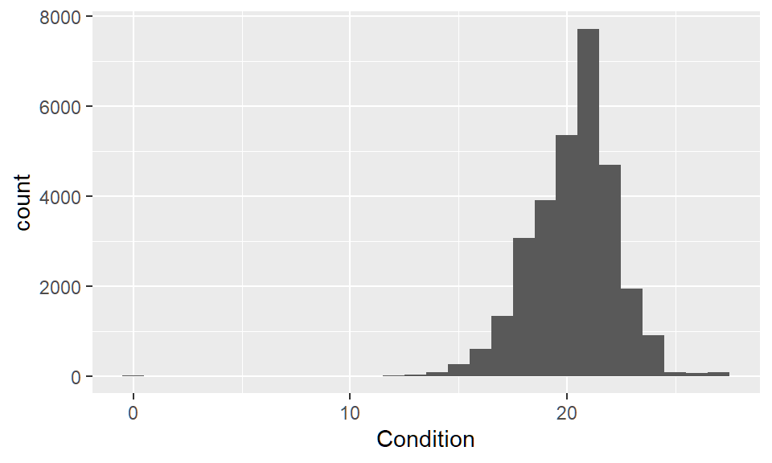

Figure 2

```r
data |>
  ggplot() +
  geom_histogram(aes(x = Condition), binwidth = 1)
```

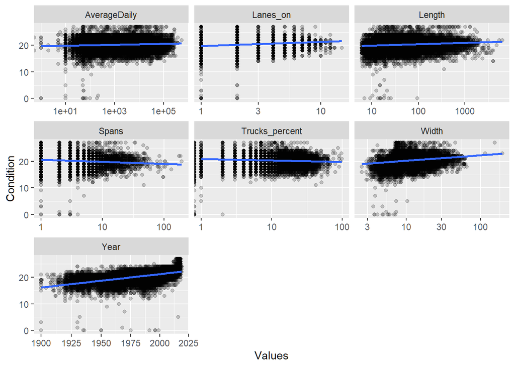

Figure 3: Scatterplot of covariate and the response variable `Condition` (x-axis is in log scale).

```r
data |>
  select(where(is.numeric)) |>
  pivot_longer(-Condition, names_to = "covariate", values_to = "Values") |>
  ggplot(aes(x = Values, y = Condition)) +
  geom_point(alpha = 1/5) +
  geom_smooth(method = "lm") +
  scale_x_log10() +
  facet_wrap(~covariate, scales = "free_x")
```

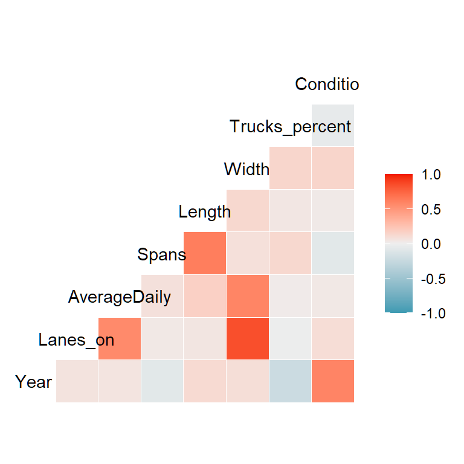

Figure 4: Correlation heatmap between numeric covariates

```r
GGally::ggcorr(data)
```

As for the correlation between covariates, we notice that `Lanes_on` and `Width` has remarkably high positive correlation, while other pairs such as `Lanes_on` and `AverageDaily`, `Length` and `Spans` and `Width` and `AverageDaily` shows moderately positive correlation. On the other hand, `Year` and `Trucks_percent` has moderately negative correlation, indicating that more trucks cross older bridges.

## 3.2 Categorical covariates

There are three categorical covariates in the dataset, namely `Historic`, `Urban` and `Material`. First, we plot the heat map of counts for `Historic` and `Material` corresponding to the levels of `Urban` (Figure 5). It is clearly seen that most bridges are either *not historic* or *possibly historic*. In terms of the `Material`, `Steel` and `Concrete` are the most common ones.

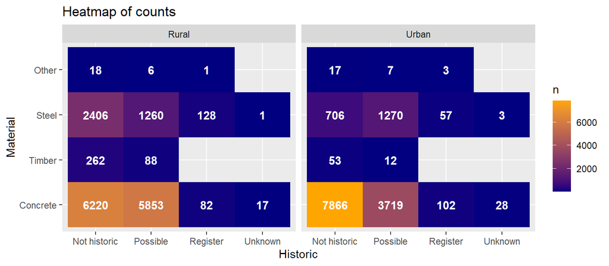

Figure 5: Count of combinations of `Historic` and `Material`, corresponding to different levels of `Urban`.

```r
data |>
  count(Historic, Material, Urban) |>
  ggplot(aes(x = Historic, y = Material, fill = n)) +
  geom_tile() +
  geom_text(aes(label = n), color = "white", fontface = "bold") +
  facet_grid(. ~ Urban) +
  scale_fill_gradient(low = "navy", high = "orange") +
  labs(title = "Heatmap of counts")
```

We now examine the categorical covariates and their relationship with the response variable.

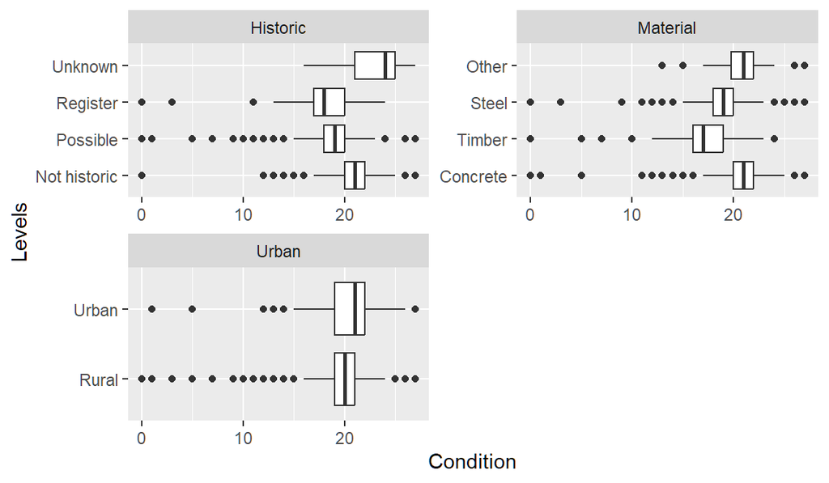

Figure 6: Distribution of `Condition` corresponding to levels of categorical covariates.

```r
data |>
  select(!where(is.numeric) & !Structure_id, Condition) |>
  pivot_longer(!Condition, names_to = "covariate", values_to = "Levels") |>
  ggplot() +
  geom_boxplot(aes(x = Levels, y = Condition)) +
  facet_wrap(~covariate, scales = "free", nrow = 2) +
  coord_flip()
```

As observed from the box plots (Figure 6), bridges with `Unknown` `Historic` have fairly higher condition than other levels, while bridges made of `Timber` has slightly worse condition. In terms of `Urban`, there is no significant variation in the condition between two levels.

# 4 Methods

## 4.1 Model proposal

We propose three models to analyze how the covariates may explain the condition of bridges.

1. A multiple linear regression model with no interaction.
2. A multiple linear regression model with transformation for some covariates and no interaction.
3. A multiple linear regression model with interactions.

For model 2, we decide to log-transform `Width`, `Length`, `AverageDaily`, `Trucks_percent` and `Spans` due to the skewness and large range of the values. Also, it might be easier to interpret the coefficients after log-transformation as different in Condition mean when increasing covariates in proportions.

For model 3, when adding interactions, we consider the following points:

- `log(Length) * log(Spans)`: Long bridges with more spans are more strong, which means their condition might be better.
- `log(AverageDaily + 1) * Material` and `log(Trucks_percent + 1) * Material`: The amount of daily traffic’s impact on bridge condition might depend on the material used to build the bridge, as different materials have different capacity tolerate pressure. This is similar for the percentage of trucks.
- `Year:Material`: Similarly, bridges built with different material might have different wear-out rate over time.

```r
model <- lm(Condition ~ ., data = select(data, -Structure_id))
model2 <- lm(Condition ~
               Urban + Historic + Material + Year +
               log(AverageDaily + 1) +
               log(Width) + log(Spans) + log(Length) +
               log(Trucks_percent + 1) + Lanes_on, data = dplyr::select(data, -Structure_id))
model3 <- lm(Condition ~ Urban + Historic +
               Year * Material +log(AverageDaily + 1) * Material +
               log(Trucks_percent + 1) * Material +
               log(Spans) * log(Length) +
               log(Width) + Lanes_on, data = dplyr::select(data, -Structure_id))
```

## 4.2 Model result and interpretation

### 4.2.1 Model result

#### 4.2.1.1 Model 1

```r
summ(model, digits = 4)
```

| Observations | 30185 |
| --- | --- |
| Dependent variable | Condition |
| Type | OLS linear regression |

| F(14,30170) | 1871.4316 |
| --- | --- |
| R² | 0.4648 |
| Adj. R² | 0.4645 |

|  | Est. | S.E. | t val. | p |
| --- | --- | --- | --- | --- |
| (Intercept) | -83.7048 | 1.3470 | -62.1414 | 0.0000 |
| UrbanUrban | -0.0230 | 0.0199 | -1.1572 | 0.2472 |
| Year | 0.0526 | 0.0007 | 78.0157 | 0.0000 |
| Lanes_on | -0.0486 | 0.0137 | -3.5529 | 0.0004 |
| AverageDaily | -0.0000 | 0.0000 | -5.4291 | 0.0000 |
| HistoricPossible | 0.2864 | 0.0322 | 8.8916 | 0.0000 |
| HistoricRegister | 0.4497 | 0.0869 | 5.1770 | 0.0000 |
| HistoricUnknown | 1.3411 | 0.2097 | 6.3961 | 0.0000 |
| MaterialTimber | -3.2034 | 0.0736 | -43.5408 | 0.0000 |
| MaterialSteel | -1.3758 | 0.0232 | -59.4204 | 0.0000 |
| MaterialOther | 0.2557 | 0.2035 | 1.2568 | 0.2088 |
| Spans | -0.0356 | 0.0023 | -15.4854 | 0.0000 |
| Length | 0.0003 | 0.0001 | 4.2343 | 0.0000 |
| Width | 0.0213 | 0.0028 | 7.7072 | 0.0000 |
| Trucks_percent | 0.0031 | 0.0009 | 3.3612 | 0.0008 |

Standard errors: OLS

We first call our attention to the high p-values of coefficients corresponding to `Urban` level of `Urban` covariate and `Other` level of `Material` covariate. In this dummy variable coding, `Rural` and `Concrete` are used as the reference level, respectively.

Despite having very low p-values, which means *statistical significance*, some covariates, namely `AverageDaily`, `Length`, `Width`, `Spans` and `Trucks_percent` have very small coefficients (and also very small standard error, which leads to low p-values). This might be explained by high range of values of these covariates in the dataset, which lead to our choice of log-transformation.

#### 4.2.1.2 Model 2

```r
summ(model2, digits = 4)
```

| Observations | 30185 |
| --- | --- |
| Dependent variable | Condition |
| Type | OLS linear regression |

| F(14,30170) | 1939.4063 |
| --- | --- |
| R² | 0.4737 |
| Adj. R² | 0.4734 |

|  | Est. | S.E. | t val. | p |
| --- | --- | --- | --- | --- |
| (Intercept) | -81.3640 | 1.3687 | -59.4463 | 0.0000 |
| UrbanUrban | -0.0600 | 0.0235 | -2.5511 | 0.0107 |
| HistoricPossible | 0.2631 | 0.0319 | 8.2491 | 0.0000 |
| HistoricRegister | 0.4484 | 0.0869 | 5.1634 | 0.0000 |
| HistoricUnknown | 1.3761 | 0.2078 | 6.6219 | 0.0000 |
| MaterialTimber | -2.9799 | 0.0741 | -40.2267 | 0.0000 |
| MaterialSteel | -1.3354 | 0.0233 | -57.3125 | 0.0000 |
| MaterialOther | 0.2332 | 0.2019 | 1.1553 | 0.2480 |
| Year | 0.0509 | 0.0007 | 73.8577 | 0.0000 |
| log(AverageDaily + 1) | -0.0161 | 0.0068 | -2.3511 | 0.0187 |
| log(Width) | 0.7126 | 0.0425 | 16.7706 | 0.0000 |
| log(Spans) | -0.2958 | 0.0161 | -18.3947 | 0.0000 |
| log(Length) | 0.0231 | 0.0138 | 1.6782 | 0.0933 |
| log(Trucks_percent + 1) | 0.0383 | 0.0089 | 4.3057 | 0.0000 |
| Lanes_on | -0.1590 | 0.0122 | -13.0499 | 0.0000 |

Standard errors: OLS

To compare the “effects” of different covariates, we standardize the coefficients and plot their values, shown in Figure 7. It can be seen that `Year` seem to be the most important in explaining bridges condition, as expected from its high correlation with `Condition` in the Explanatory Data Analysis section. In contrast, `Material` seems to negatively affect bridge condition the most.

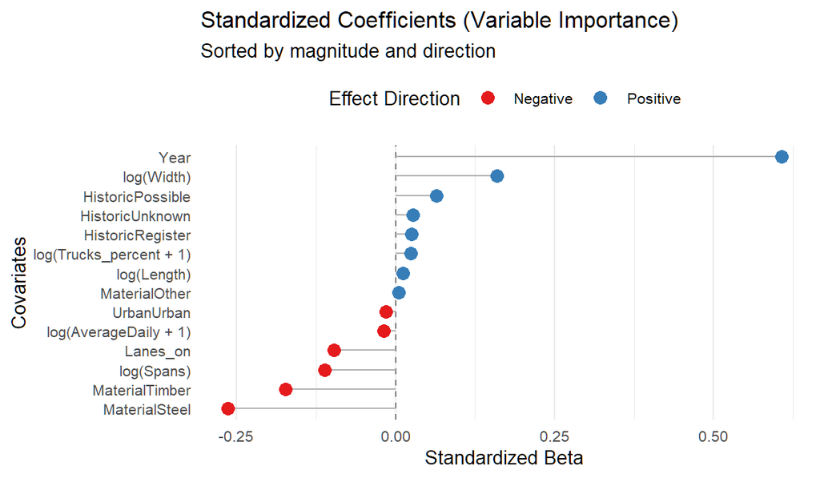

Figure 7: Standardized Coeffients (sorted by magnitude and direction)

```r
std_model <- lm.beta(model2)
coef_df <- data.frame(
    Term = names(std_model$standardized.coefficients),
    Estimate = std_model$standardized.coefficients, row.names = NULL
    ) |>
    filter(Term != "(Intercept)") |>
    mutate(Direction = ifelse(Estimate > 0, "Positive", "Negative"))
ggplot(coef_df, aes(x = Estimate, y = reorder(Term, Estimate))) +
    geom_vline(xintercept = 0, linetype = "dashed", color = "gray50") +
    geom_segment(aes(xend = 0, yend = Term), color = "gray70") +
    geom_point(aes(color = Direction), size = 3) +
    scale_color_manual(values = c("Negative" = "#E41A1C", "Positive" = "#377EB8")) +
    labs(
      title = "Standardized Coefficients (Variable Importance)",
      subtitle = "Sorted by magnitude and direction",
      x = "Standardized Beta", y = "Covariates", color = "Effect Direction"
    ) +
    theme_minimal() +
    theme(legend.position = "top", panel.grid.major.y = element_blank(), text = element_text(size = 10)
    )
```

#### 4.2.1.3 Model 3

```r
summ(model3, digits = 4)
```

| Observations | 30185 |
| --- | --- |
| Dependent variable | Condition |
| Type | OLS linear regression |

| F(24,30160) | 1240.8014 |
| --- | --- |
| R² | 0.4968 |
| Adj. R² | 0.4964 |

|  | Est. | S.E. | t val. | p |
| --- | --- | --- | --- | --- |
| (Intercept) | -84.1822 | 1.4078 | -59.7952 | 0.0000 |
| UrbanUrban | -0.1007 | 0.0230 | -4.3711 | 0.0000 |
| HistoricPossible | 0.1381 | 0.0315 | 4.3835 | 0.0000 |
| HistoricRegister | 0.2836 | 0.0856 | 3.3114 | 0.0009 |
| HistoricUnknown | 1.2318 | 0.2033 | 6.0601 | 0.0000 |
| Year | 0.0529 | 0.0007 | 74.8225 | 0.0000 |
| MaterialTimber | -13.8530 | 8.1046 | -1.7093 | 0.0874 |
| MaterialSteel | 14.8446 | 1.8282 | 8.1198 | 0.0000 |
| MaterialOther | 21.0470 | 12.5042 | 1.6832 | 0.0923 |
| log(AverageDaily + 1) | -0.0575 | 0.0069 | -8.3278 | 0.0000 |
| log(Trucks_percent + 1) | 0.0220 | 0.0092 | 2.3879 | 0.0170 |
| log(Spans) | -0.5051 | 0.0429 | -11.7878 | 0.0000 |
| log(Length) | -0.1630 | 0.0167 | -9.7395 | 0.0000 |
| log(Width) | 0.6493 | 0.0416 | 15.5940 | 0.0000 |
| Lanes_on | -0.1572 | 0.0119 | -13.1885 | 0.0000 |
| Year:MaterialTimber | 0.0045 | 0.0041 | 1.1060 | 0.2687 |
| Year:MaterialSteel | -0.0091 | 0.0009 | -9.9347 | 0.0000 |
| Year:MaterialOther | -0.0126 | 0.0062 | -2.0161 | 0.0438 |
| MaterialTimber:log(AverageDaily + 1) | 0.2877 | 0.0518 | 5.5528 | 0.0000 |
| MaterialSteel:log(AverageDaily + 1) | 0.2565 | 0.0107 | 24.0422 | 0.0000 |
| MaterialOther:log(AverageDaily + 1) | 0.5580 | 0.1082 | 5.1559 | 0.0000 |
| MaterialTimber:log(Trucks_percent + 1) | 0.6084 | 0.1461 | 4.1633 | 0.0000 |
| MaterialSteel:log(Trucks_percent + 1) | 0.0903 | 0.0229 | 3.9481 | 0.0001 |
| MaterialOther:log(Trucks_percent + 1) | -0.1931 | 0.2114 | -0.9135 | 0.3610 |
| log(Spans):log(Length) | 0.0603 | 0.0088 | 6.8833 | 0.0000 |

Standard errors: OLS

The interaction term `log(Spans):log(Length)` is positive (+0.060). This confirms our intuition that increasing the number of spans for a given length helps mitigate the drop in condition. Physically, this implies that a long bridge divided into many shorter spans (shorter average span length) is structurally more robust or resilient than a long bridge with fewer, longer spans.

## 4.3 Model diagnostics

### 4.3.1 Diagnostic plots

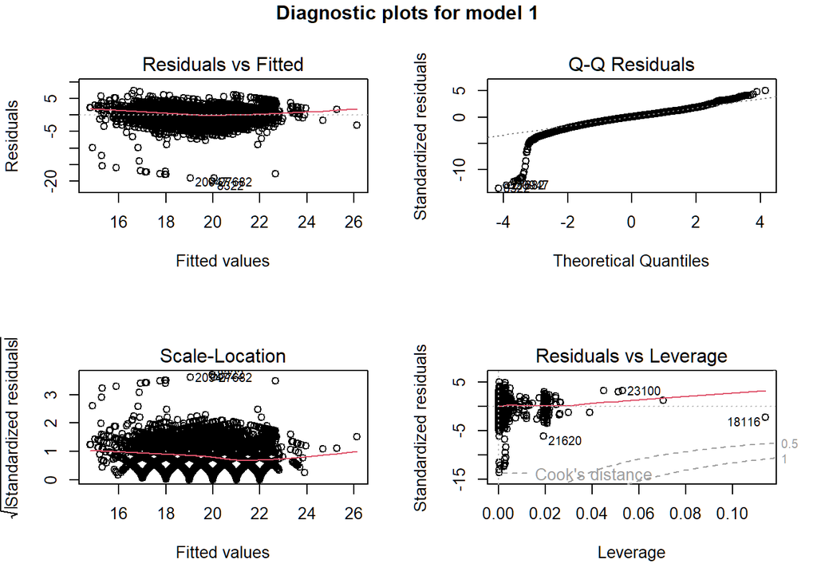

Figure 8: Diagnostic plots for model 1

```r
par(mfrow=c(2,2))
plot(model)
title("Diagnostic plots for model 1", line = -1, outer = TRUE)
```

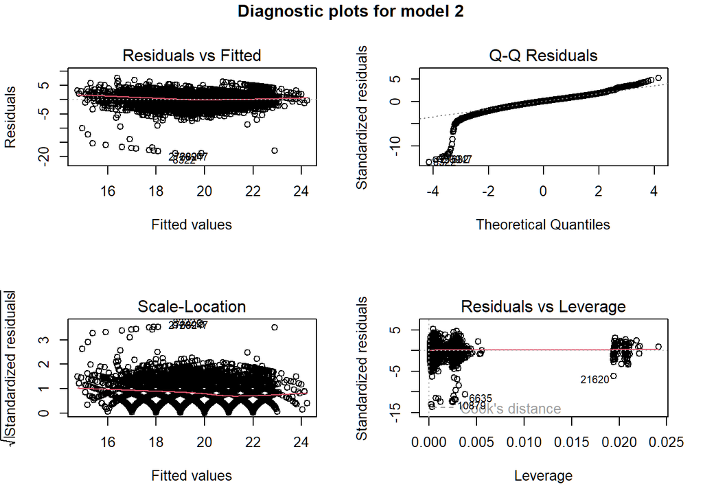

Figure 9: Diagnostic plots for model 2

```r
par(mfrow=c(2,2))
plot(model2)
title("Diagnostic plots for model 2", line = -1, outer = TRUE)
```

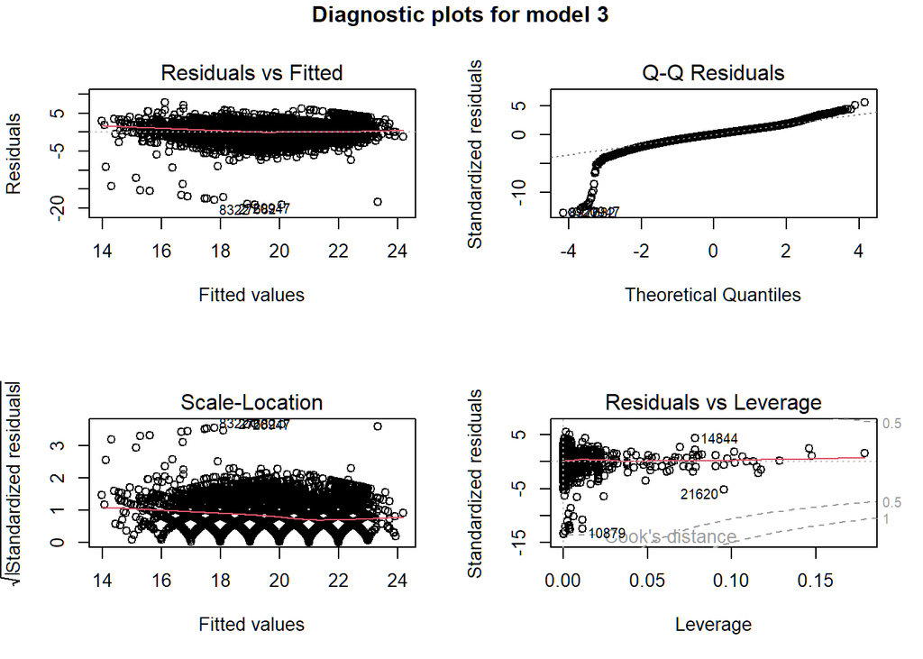

Figure 10: Diagnostic plots for model 3

```r
par(mfrow=c(2,2))
plot(model3)
title("Diagnostic plots for model 3", line = -1, outer = TRUE)
```

### 4.3.2 Test for Multicollinearity

To check for multicollinearity, we can examine the covariates’ Variance Inflation Factor (VIF).

```r
vif1 <- car::vif(model)
vif2 <- car::vif(model2)
vif3 <- car::vif(model3)
```

```r
output <- c(
  "Model 1",
  "VIFs (adjusted for GVIF^(1/(2*Df))^2):",
  paste(capture.output(print(vif1[,"GVIF^(1/(2*Df))"] ** 2)), collapse = "\n"),
  "",
  "Model 2",
  "VIFs (adjusted for GVIF^(1/(2*Df))^2):",
  paste(capture.output(print(vif2[,"GVIF^(1/(2*Df))"] ** 2)), collapse = "\n"),
  "",
  "Model 3",
  "VIFs (adjusted for GVIF^(1/(2*Df))^2):",
  paste(capture.output(print(vif3[,"GVIF^(1/(2*Df))"] ** 2)), collapse = "\n"),
  ""
)

cat(paste(output, collapse = "\n"))
```

```
Model 1
VIFs (adjusted for GVIF^(1/(2*Df))^2):
         Urban           Year       Lanes_on   AverageDaily       Historic
      1.380246       3.644908       3.950892       1.695395       1.548379
      Material          Spans         Length          Width Trucks_percent
      1.063428       1.829443       1.943687       4.332562       1.292528

Model 2
VIFs (adjusted for GVIF^(1/(2*Df))^2):
                  Urban                Historic                Material
               1.964259                1.557112                1.085859
                   Year   log(AverageDaily + 1)              log(Width)
               3.874646                3.495742                5.158045
             log(Spans)             log(Length) log(Trucks_percent + 1)
               2.132794                2.781720                1.807807
               Lanes_on
               3.187854

Model 3
VIFs (adjusted for GVIF^(1/(2*Df))^2):
                           Urban                         Historic
                        1.972920                         1.582627
                            Year                         Material
                        4.273112                      7462.665249
           log(AverageDaily + 1)          log(Trucks_percent + 1)
                        3.734759                         2.027717
                      log(Spans)                      log(Length)
                       15.838874                         4.281622
                      log(Width)                         Lanes_on
                        5.178814                         3.189638
                   Year:Material   Material:log(AverageDaily + 1)
                     7386.664203                        14.885506
Material:log(Trucks_percent + 1)           log(Spans):log(Length)
                        2.170009                        19.657042
```

We can see that `Width` has the highest VIF in model 1 and 2. This is due the high correlation between `Width` and `Lanes_on`, as discussed in the Exploratory Data Analysis section. For model 3, since there are some interaction terms, high VIFs are expected.

To deal with high VIF of `Width` in model 1 and 2, we can either replace `Width` or `Lanes_on` with `Width/Lanes_on`, which is the width per lane.

```r
model12 <- update(model, . ~ . - Lanes_on + I(Width/Lanes_on))
model22 <- update(model2, . ~ . - Lanes_on + I(Width/Lanes_on))
```

```r
vif1 <- car::vif(model12)[,"GVIF^(1/(2*Df))"] ** 2
vif2 <- car::vif(model22)[,"GVIF^(1/(2*Df))"] ** 2

output <- c(
  "Model 1 (use Width/Lanes_on instead of Lanes_on)",
  "VIFs (adjusted for GVIF^(1/(2*Df))^2):",
  paste(capture.output(print(vif1)), collapse = "\n"),
  "",
  "Model 2 (use Width/Lanes_on instead of Lanes_on)",
  "VIFs (adjusted for GVIF^(1/(2*Df))^2):",
  paste(capture.output(print(vif2)), collapse = "\n"),
  ""
)

cat(paste(output, collapse = "\n"))
```

```
Model 1 (use Width/Lanes_on instead of Lanes_on)
VIFs (adjusted for GVIF^(1/(2*Df))^2):
            Urban              Year      AverageDaily          Historic
         1.386127          3.643268          1.691335          1.548728
         Material             Spans            Length             Width
         1.063332          1.830931          1.962182          1.894603
   Trucks_percent I(Width/Lanes_on)
         1.308567          1.268410

Model 2 (use Width/Lanes_on instead of Lanes_on)
VIFs (adjusted for GVIF^(1/(2*Df))^2):
                  Urban                Historic                Material
               1.957385                1.556865                1.085412
                   Year   log(AverageDaily + 1)              log(Width)
               3.873061                3.486265                2.280511
             log(Spans)             log(Length) log(Trucks_percent + 1)
               2.131960                2.779059                1.743676
      I(Width/Lanes_on)
               1.284440
```

Now we can see that all VIFs are relatively low.

## 4.4 Building Linear Regression model for prediction

### 4.4.1 More complex models

```r
model3_poly <- lm(Condition ~ Urban*Historic +
               poly(Year, 5) * Material +
               poly(log(AverageDaily + 1), 5) * poly(log(Width), 4) +
               poly(log(AverageDaily + 1), 5) * poly(log(Length + 1), 2) +
               poly(log(Spans + 1), 4) * poly(log(Length + 1), 2) +
               poly(log(Trucks_percent + 1), 2) * Material +
               poly(log(AverageDaily + 1), 5) * Material +
               I(Width/Lanes_on), data = dplyr::select(data, -Structure_id))
```

### 4.4.2 Model evaluation

We decide to evaluate the models based on the following metrics:

- **Adjusted** $R^2$: Adjusted $R^2$ penalizes for the number of predictors $p$, using the formula: $\text{Adjusted } R^2 = 1 - (1 - R^2) \frac{n-1}{n-p-1}$.
- **Akaike Information Criterion (AIC)**: $\text{AIC} = -2 \log(\mathcal{L}) + 2p$, where $\mathcal{L}$ is the maximized likelihood, and $p$ is the number of parameters. AIC estimates the relative quality of models for prediction, balancing goodness-of-fit (via log-likelihood) with parsimony. Lower AIC values are preferred.
- **Predicted Residual Error Sum of Squares (PRESS)**: PRESS is a direct measure of predictive performance, computed via leave-one-out cross-validation (LOOCV): for each observation $i$, refit the model excluding it, predict its value, and square the residual, then take the sum: $\text{PRESS} = \sum_{i=1}^n (y_i - \hat{y}_{(-i)})^2$
- **k-fold Cross Validation (k = 8)**: Splits data into 8 folds; trains on 7 and tests on 1, then computing the root mean square prediction error (RMSPE) across folds. This provides robust estimate of predictive performance.

```r
models <- list(model, model2, model3, model12, model22, model3_poly)
models.names <- c("Simple Model", "Model with Tranformation",
                      "Model with Interaction", "Simple Model (low VIF)",
                      "Model with Tranformation (low VIF)", "Complex Model")
```

```r
k <- 8
n <- nrow(data)

set.seed(123)  # For reproducibility
folds <- sample(1:k, n, replace = TRUE)

rmspe_results <- matrix(NA, nrow = k, ncol = length(models))
colnames(rmspe_results) <- models.names

# Perform k-fold CV
for (i in 1:k) {
  train_data <- data[folds != i, ]
  test_data  <- data[folds == i, ]

  for (j in seq_along(models)) {
    formula <- models[[j]]$call$formula
    fit <- lm(formula, data = select(train_data, -Structure_id))
    pred <- predict(fit, newdata = test_data)
    actual <- test_data$Condition
    rmspe_results[i, j] <- sqrt(mean((actual - pred)^2))
  }
  rm(train_data, test_data, fit, formula, pred)
}
```

```r
measures <- function(model) {
  summ <- summary(model)
  data.frame(df = summ$df[1],
             adjR2 = summ$adj.r.squared,
             AIC = AIC(model),
             PRESS = sum(rstandard(model, type="pred")^2))
}

results <- do.call(rbind, lapply(models, measures))
results$RMSPE <- colMeans(rmspe_results)
rownames(results) <- models.names
results
```

Table 1: Evaluation results of 6 fitted models using adjusted R-squared, AIC, PRESS and k-fold cross validation.

|  | df | adjR2 | AIC | PRESS | RMSPE |
| --- | --- | --- | --- | --- | --- |
| Simple Model | 15 | 0.4645383 | 108703.6 | 64804.07 | 1.464306 |
| Model with Tranformation | 15 | 0.4734279 | 108198.3 | 63717.51 | 1.452078 |
| Model with Interaction | 25 | 0.4964233 | 106860.5 | 61012.27 | 1.420870 |
| Simple Model (low VIF) | 15 | 0.4654035 | 108654.8 | 64698.71 | 1.463086 |
| Model with Tranformation (low VIF) | 15 | 0.4710315 | 108335.3 | 64007.84 | 1.455358 |
| Complex Model | 108 | 0.5489670 | 103617.0 | 56378.61 | 1.368737 |

As can be seen in Table 1, the metrics are consistent in evaluating the performance of the models. It can clearly be seen that the model with interaction has better scores than those without interaction, even if these metrics adjust for the number of parameters. The best model is our proposed complex model with polynomial transformations, outperforming other models by a large margin on every metric. Therefore, we choose the last model to predict the condition on new data.

### 4.4.3 Prediction on new data

```r
test_data <- read_csv("data/predict.csv", col_types = cols(
  Urban = col_factor(),
  Historic = col_factor(),
  Material = col_factor(),
))
test_data$Material <- forcats::fct_collapse(test_data$Material, Other = c("Masonry", "Other"))
```

```r
pred <- predict(model3_poly, newdata = test_data)
predictions <- data.frame(
  Structure_id = test_data$Structure_id,
  Condition = pred
)
head(predictions)
```

Table 2: Prediction result on new dataset

|  | Structure_id | Condition |
| --- | --- | --- |
| 1 | 090980AA0158001 | 21.24209 |
| 2 | 150150001701045 | 18.33857 |
| 3 | 131580AA0146001 | 18.99850 |
| 4 | 060690000407036 | 19.10273 |
| 5 | 111140AA0302004 | 18.81794 |
| 6 | 161780010201130 | 21.79191 |

# 5 Conclusion

In this report, we performed an exploratory data analysis of the bridge dataset and proposed some linear regression models to explain how the covariates can affect the bridge condition. We found out that `Year`, `Width` and `Material` seem to be the most important covariates. As for interaction, most of them are statistically significant, namely `Year:Material` and `Spans:Length`, which describes how a covariate’s effect may depend on another. We also took measures to handle the slightly high Variance Inflation Factor of the model. For predicting the condition for a new set of bridges, we propose a new, more complex model with polynomials, which has superior predictive power. This is reflected in our model evaluation, in which we computed several metrics such as AIC, PRESS and RMSPE for k-fold cross validation.